# AI 프로그래밍 과제 3

## Problem: Pandas 를 이용하여 "vehicle_info.csv" 파일을 읽고 아래의 문제들에서 요구된 조건에 만족하도록 코드를 작성하시오.

```python
import numpy as np
import pandas as pd
import matplotlib.pyplot as plt
```

```python
#저장시 공란 발생
!cat vehicle_info.csv
```

### 문제1: "vehicle_info.csv" 파일을 읽어서 df 라는 데이터프레임에 저장하기 - (1 point)

```python
"""
이 셀 안에 코드를 작성하시오.
"""
#엑셀파일에 columns name이 없어서 head = None으로 하여 비워둠
#
df = pd.read_csv("vehicle_info.csv",index_col = None,header = None)
```

### 문제2: df 데이터프레임의 맨 앞 5개 행까지만 출력하기 (head 함수 이용) - (1 point)

```python
"""
이 셀 안에 코드를 작성하시오.
"""
df.head()
```

|  | 0 | 1 | 2 | 3 | 4 | 5 | 6 | 7 | 8 |
| --- | --- | --- | --- | --- | --- | --- | --- | --- | --- |
| 0 | 18.0 | 8 | 307.0 | 130.0 | 3504.0 | 12.0 | 70 | 1 | chevrolet chevelle malibu |
| 1 | 15.0 | 8 | 350.0 | 165.0 | 3693.0 | 11.5 | 70 | 1 | buick skylark 320 |
| 2 | 18.0 | 8 | 318.0 | 150.0 | 3436.0 | 11.0 | 70 | 1 | plymouth satellite |
| 3 | 16.0 | 8 | 304.0 | 150.0 | 3433.0 | 12.0 | 70 | 1 | amc rebel sst |
| 4 | 17.0 | 8 | 302.0 | 140.0 | 3449.0 | 10.5 | 70 | 1 | ford torino |

### 문제3: df 데이터프레임의 맨 뒤 5개 행까지만 출력하기 (tail 함수 이용) - (1 point)

```python
"""
이 셀 안에 코드를 작성하시오.
"""
df.tail()
```

|  | 0 | 1 | 2 | 3 | 4 | 5 | 6 | 7 | 8 |
| --- | --- | --- | --- | --- | --- | --- | --- | --- | --- |
| 393 | 27.0 | 4 | 140.0 | 86.00 | 2790.0 | 15.6 | 82 | 1 | ford mustang gl |
| 394 | 44.0 | 4 | 97.0 | 52.00 | 2130.0 | 24.6 | 82 | 2 | vw pickup |
| 395 | 32.0 | 4 | 135.0 | 84.00 | 2295.0 | 11.6 | 82 | 1 | dodge rampage |
| 396 | 28.0 | 4 | 120.0 | 79.00 | 2625.0 | 18.6 | 82 | 1 | ford ranger |
| 397 | 31.0 | 4 | 119.0 | 82.00 | 2720.0 | 19.4 | 82 | 1 | chevy s-10 |

### 문제4: df 데이터프레임에 열(column) 이름을 아래와 같이 지정하고 df 데이터프레임의 앞부분의 행 출력하기 (head 함수 이용) - (1 point)

- ['mpg', 'cylinders', 'displacement', 'horsepower', 'weight', 'asseleration', 'model year', 'origin', 'name']

```python
"""
이 셀 안에 코드를 작성하시오.
"""
df.columns = ['mpg', 'cylinders', 'displacement', 'horsepower', 'weight', 'asseleration', 'model year', 'origin', 'name']
df.head()
```

|  | mpg | cylinders | displacement | horsepower | weight | asseleration | model year | origin | name |
| --- | --- | --- | --- | --- | --- | --- | --- | --- | --- |
| 0 | 18.0 | 8 | 307.0 | 130.0 | 3504.0 | 12.0 | 70 | 1 | chevrolet chevelle malibu |
| 1 | 15.0 | 8 | 350.0 | 165.0 | 3693.0 | 11.5 | 70 | 1 | buick skylark 320 |
| 2 | 18.0 | 8 | 318.0 | 150.0 | 3436.0 | 11.0 | 70 | 1 | plymouth satellite |
| 3 | 16.0 | 8 | 304.0 | 150.0 | 3433.0 | 12.0 | 70 | 1 | amc rebel sst |
| 4 | 17.0 | 8 | 302.0 | 140.0 | 3449.0 | 10.5 | 70 | 1 | ford torino |

### 문제5: 데이터프레임 df의 각 열이 가지고 있는 원소의 개수 확인하기 - (1 point)

```python
"""
이 셀 안에 코드를 작성하시오.
"""
df.count(axis = 'rows')
```

```
mpg             398
cylinders       398
displacement    398
horsepower      398
weight          398
asseleration    398
model year      398
origin          398
name            398
dtype: int64
```

### 문제6: 데이터프레임 df의 'origin' 열에 있는 원소들의 고유값 종류와 고유값 별로 원소의 개수 확인하기 (value_counts 함수 이용) - (1 point)

```python
"""
이 셀 안에 코드를 작성하시오.
"""
df['origin'].value_counts()
```

```
1    249
3     79
2     70
Name: origin, dtype: int64
```

### 문제7: 데이터프레임 df의 'mpg' 열에 있는 원소들의 평균값, 중간값, 최대값, 최소값, 표준편차 확인하기 - (1 point)

```python
"""
이 셀 안에 코드를 작성하시오.
"""
print(df['mpg'].mean())
print(df['mpg'].median())
print(df['mpg'].max())
print(df['mpg'].min())
print(df['mpg'].std())
```

```
23.514572864321615
23.0
46.6
9.0
7.815984312565782
```

### 문제8: x축은 'weight', y축은 'mpg' 열을 이용하여 scatter(산점도) 그래프를 만들고 'output.png' 라는 파일이름으로 그래프를 저장하기 - (1 point)

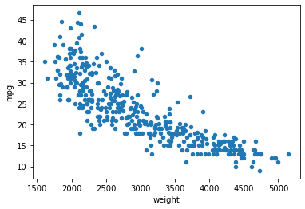

```python
"""
이 셀 안에 코드를 작성하시오.
"""
plt.scatter(df['weight'],df['mpg'],s=20)
plt.xlabel("weight")
plt.ylabel("mpg")
plt.savefig("output.png")
plt.show()
```

### 문제9: 'model year' 열을 오름차순으로 정렬하여 df 데이터프레임을 정렬하기 (sort_values 함수 이용) - (1 point)

```python
"""
이 셀 안에 코드를 작성하시오.
"""
myDf = df.sort_values('model year',ascending = True)
myDf
```

|  | mpg | cylinders | displacement | horsepower | weight | asseleration | model year | origin | name |
| --- | --- | --- | --- | --- | --- | --- | --- | --- | --- |
| 0 | 18.0 | 8 | 307.0 | 130.0 | 3504.0 | 12.0 | 70 | 1 | chevrolet chevelle malibu |
| 28 | 9.0 | 8 | 304.0 | 193.0 | 4732.0 | 18.5 | 70 | 1 | hi 1200d |
| 27 | 11.0 | 8 | 318.0 | 210.0 | 4382.0 | 13.5 | 70 | 1 | dodge d200 |
| 26 | 10.0 | 8 | 307.0 | 200.0 | 4376.0 | 15.0 | 70 | 1 | chevy c20 |
| 25 | 10.0 | 8 | 360.0 | 215.0 | 4615.0 | 14.0 | 70 | 1 | ford f250 |
| ... | ... | ... | ... | ... | ... | ... | ... | ... | ... |
| 368 | 27.0 | 4 | 112.0 | 88.00 | 2640.0 | 18.6 | 82 | 1 | chevrolet cavalier wagon |
| 367 | 28.0 | 4 | 112.0 | 88.00 | 2605.0 | 19.6 | 82 | 1 | chevrolet cavalier |
| 396 | 28.0 | 4 | 120.0 | 79.00 | 2625.0 | 18.6 | 82 | 1 | ford ranger |
| 381 | 36.0 | 4 | 107.0 | 75.00 | 2205.0 | 14.5 | 82 | 3 | honda accord |
| 397 | 31.0 | 4 | 119.0 | 82.00 | 2720.0 | 19.4 | 82 | 1 | chevy s-10 |

398 rows × 9 columns

### 문제10: 'name' 열을 내림차순으로 정렬하여 df 데이터프레임을 정렬하기 - (1 point)

```python
"""
이 셀 안에 코드를 작성하시오.
"""
myDf = df.sort_values('name',ascending = False)
myDf
```

|  | mpg | cylinders | displacement | horsepower | weight | asseleration | model year | origin | name |
| --- | --- | --- | --- | --- | --- | --- | --- | --- | --- |
| 293 | 31.9 | 4 | 89.0 | 71.00 | 1925.0 | 14.0 | 79 | 2 | vw rabbit custom |
| 325 | 44.3 | 4 | 90.0 | 48.00 | 2085.0 | 21.7 | 80 | 2 | vw rabbit c (diesel) |
| 197 | 29.0 | 4 | 90.0 | 70.00 | 1937.0 | 14.2 | 76 | 2 | vw rabbit |
| 309 | 41.5 | 4 | 98.0 | 76.00 | 2144.0 | 14.7 | 80 | 2 | vw rabbit |
| 394 | 44.0 | 4 | 97.0 | 52.00 | 2130.0 | 24.6 | 82 | 2 | vw pickup |
| ... | ... | ... | ... | ... | ... | ... | ... | ... | ... |
| 315 | 24.3 | 4 | 151.0 | 90.00 | 3003.0 | 20.1 | 80 | 1 | amc concord |
| 257 | 19.4 | 6 | 232.0 | 90.00 | 3210.0 | 17.2 | 78 | 1 | amc concord |
| 66 | 17.0 | 8 | 304.0 | 150.0 | 3672.0 | 11.5 | 72 | 1 | amc ambassador sst |
| 9 | 15.0 | 8 | 390.0 | 190.0 | 3850.0 | 8.5 | 70 | 1 | amc ambassador dpl |
| 96 | 13.0 | 8 | 360.0 | 175.0 | 3821.0 | 11.0 | 73 | 1 | amc ambassador brougham |

398 rows × 9 columns